# Linear & Non-Linear Models (31010) Week 3 Homework Assignment Analysis of Non-Linear Dependencies

© Yuri Balasanov, iLykei 2016

**This project helps understanding properties and pitfalls of correlation as a measure of linear dependence and alternative measures more appropriate for non-linear dependence.**

**This project is individual.**

# 1 Description of the data

Data in the file `Week3_Homework_Project_Data.csv` contain observations of time during one day when people watch TV (are logged in to an internet site, active online, etc.) and their age.

Read the data and explore them.

```r
Age.Time.Sample<-read.csv(file=paste(dataPath,"Week3_Homework_Project_Data.csv",sep="/"),header=TRUE,sep=",")
Age.Time.Sample<-as.matrix(Age.Time.Sample)
Age.Time.Sample[1:10,]
```

```
##            Age     Time
##  [1,] 31.35366 22.02776
##  [2,] 27.43543 21.41511
##  [3,] 22.53053 23.37803
##  [4,] 21.00111 20.32848
##  [5,] 22.58267 21.15540
##  [6,] 29.04533 23.30662
##  [7,] 26.71073 21.56138
##  [8,] 23.61076 20.38302
##  [9,] 28.07124 21.00864
## [10,] 28.10947 20.55258
```

Visualize the data

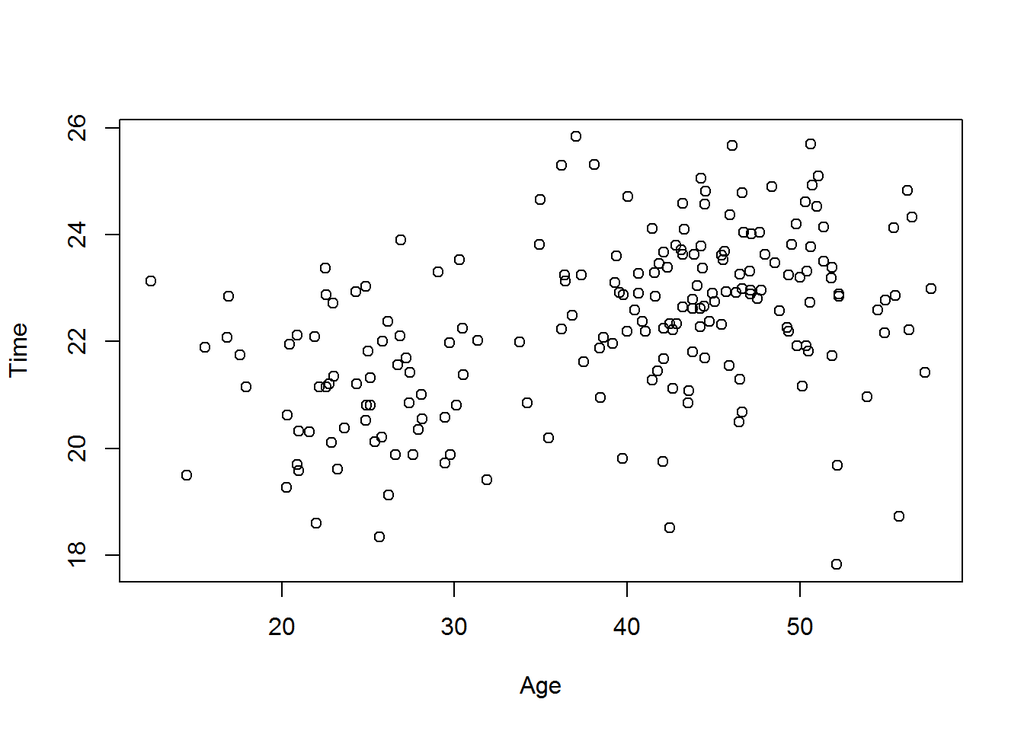

```r
plot(Age.Time.Sample)
```

Look at the empirical copula

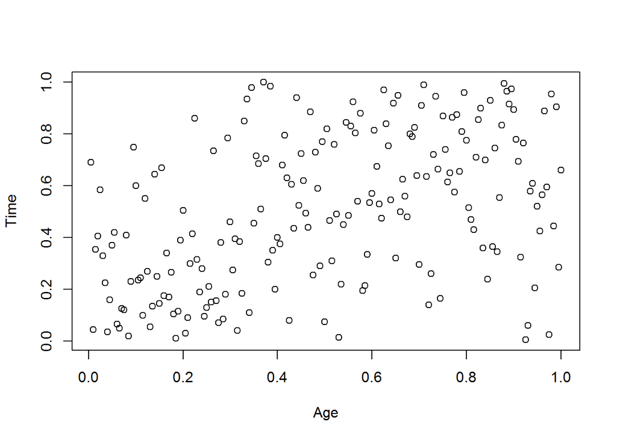

```r
plot(rank(Age.Time.Sample[,1])/length(Age.Time.Sample[,1]+1),
     rank(Age.Time.Sample[,2])/length(Age.Time.Sample[,1]+1),xlab="Age",ylab="Time")
```

Is there a correlation between the two variables?

```r
c(Correlation=cor(Age.Time.Sample)[1,2],Determination=cor(Age.Time.Sample)[1,2]^2)
```

```
##   Correlation Determination
##     0.4359003     0.1900090
```

Look at the distributions of both variables.

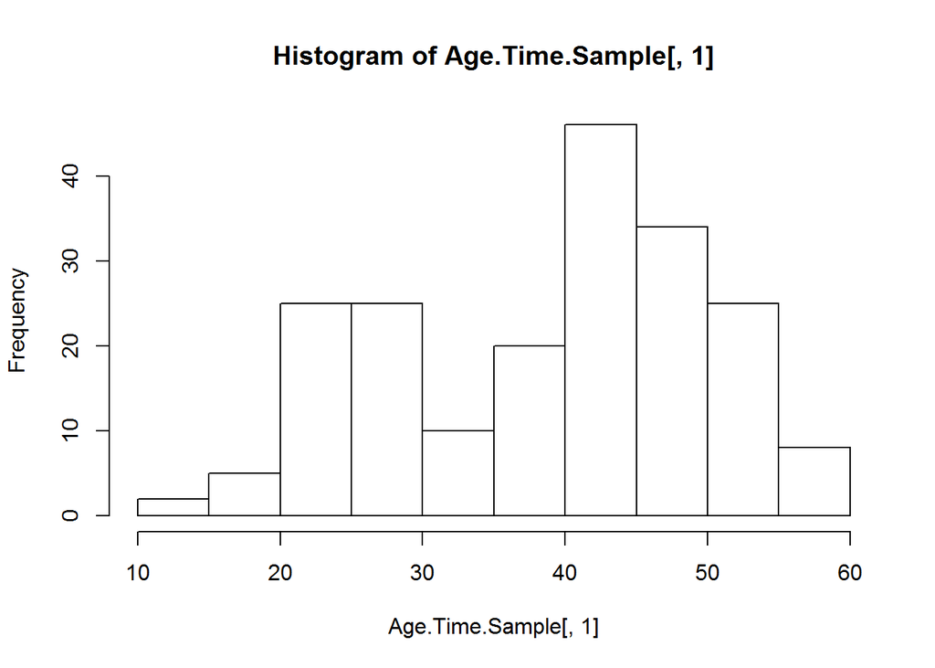

```r
hist(Age.Time.Sample[,1])
```

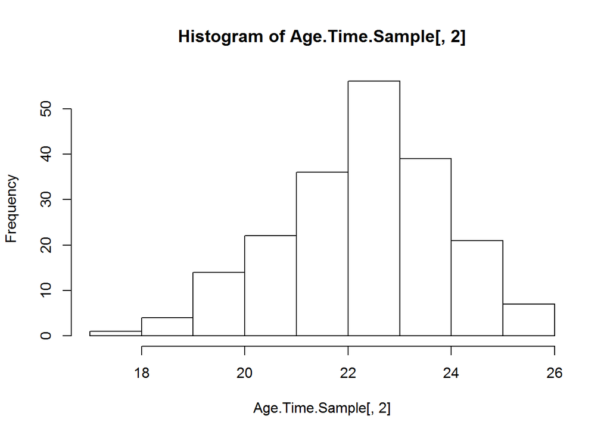

```r
hist(Age.Time.Sample[,2])
```

Interpret the initial observations:

**1. What do you see on the scatterplot of Age vs. Time?**  
**2. What does the empirical copula suggest?**  
**3. How significant is the amount of correlation?**  
**4. What do you imply from the shapes of the histograms?**

# 2 Clustering of the data.

Find possible clusters in both variables.

Use `Mclust()` from `mclust` to find clusters in the age component and time component.  
Define the `Mclust` object `Age.Clusters` and explore the components of it:

```r
library(mclust)
```

Look at the help file to learn how to use the function `Mclust()`. The object created by this function is `Age.Clusters`. Make sure you request the variances to be estimated for each cluster, not one for all clusters.

(Skipped Code)

Explore the object `Age.Clusters`

```r
names(Age.Clusters)
```

```
##  [1] "call"           "data"           "modelName"      "n"
##  [5] "d"              "G"              "BIC"            "bic"
##  [9] "loglik"         "df"             "hypvol"         "parameters"
## [13] "z"              "classification" "uncertainty"
```

```r
Age.Clusters$G
```

```
## [1] 2
```

```r
Age.Clusters$param
```

```
## $pro
## [1] 0.3181868 0.6818132
##
## $mean
##        1        2
## 24.60197 45.38063
##
## $variance
## $variance$modelName
## [1] "V"
##
## $variance$d
## [1] 1
##
## $variance$G
## [1] 2
##
## $variance$sigmasq
## [1] 20.89515 31.21728
##
## $variance$scale
## [1] 20.89515 31.21728
```

```r
Age.Clusters.Parameters<-rbind(mu=Age.Clusters$param$mean,sigma=sqrt(Age.Clusters$param$variance$sigmasq),pro=Age.Clusters$param$pro)
```

Use `norMix()` from `nor1mix` to analyze the mixed Gaussian models classified by `Mclust()`.  
Read the help file and learn how to use the function Define the object `Classified.Mix.Model.Age` using `norMix()` and plot the densities of the normal mix.

```r
library(nor1mix)
```

(Skipped Code)

Plot the mix model.

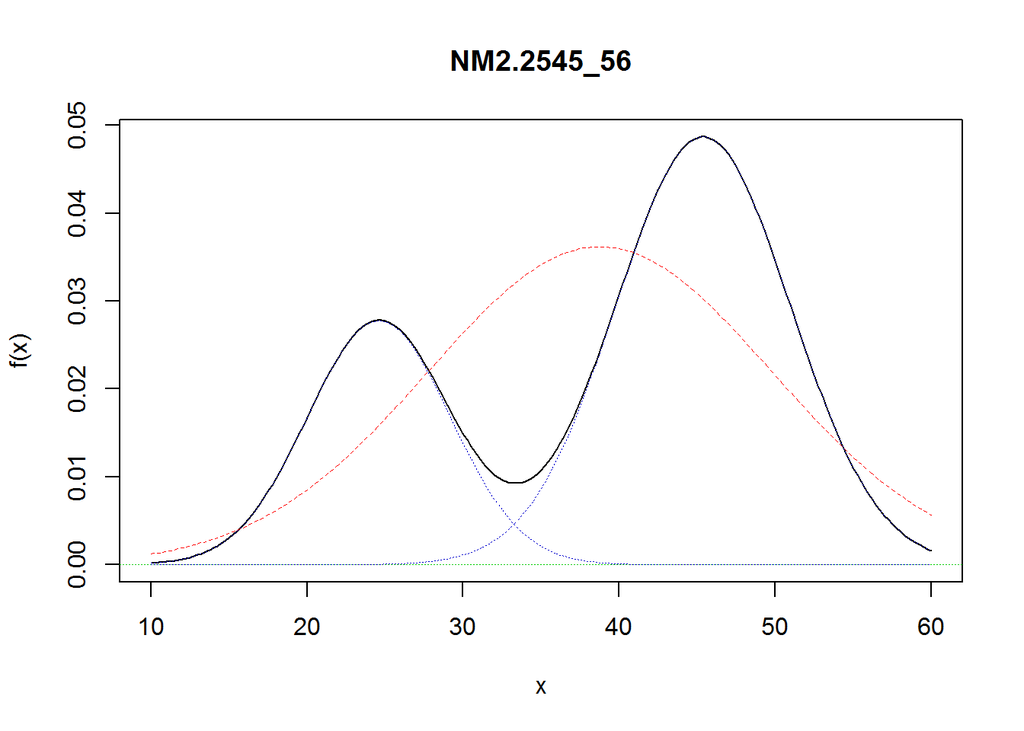

```r
plot(Classified.Mix.Model.Age,xout=seq(from=10,to=60,by=.25),p.norm=TRUE,p.comp=TRUE)
```

Define the `Mclust` object `Time.Clusters` and explore the components of it:

(Skipped Code)

```
## $pro
## [1] 1
##
## $mean
## [1] 22.31694
##
## $variance
## $variance$modelName
## [1] "X"
##
## $variance$d
## [1] 1
##
## $variance$G
## [1] 1
##
## $variance$sigmasq
## [1] 2.503304
```

You may need to force the number of mix components to be 2. Also force the variances of the mix to be different.

```r
#Force G=2
Time.Clusters<-Mclust(Age.Time.Sample[,2], G=2,modelNames=c("V"))
```

```r
names(Time.Clusters)
```

```
##  [1] "call"           "data"           "modelName"      "n"
##  [5] "d"              "G"              "BIC"            "bic"
##  [9] "loglik"         "df"             "hypvol"         "parameters"
## [13] "z"              "classification" "uncertainty"
```

```r
Time.Clusters$G
```

```
## [1] 2
```

```r
Time.Clusters$param
```

```
## $pro
## [1] 0.4657948 0.5342052
##
## $mean
##        1        2
## 21.31979 23.18639
##
## $variance
## $variance$modelName
## [1] "V"
##
## $variance$d
## [1] 1
##
## $variance$G
## [1] 2
##
## $variance$sigmasq
## [1] 2.084625 1.245452
##
## $variance$scale
## [1] 2.084625 1.245452
```

```r
Time.Clusters.Parameters<-rbind(mu=Time.Clusters$param$mean,sigma=sqrt(Time.Clusters$param$variance$sigmasq),pro=Time.Clusters$param$pro)
```

Again, define the object `Classified.Mix.Model.Time` using `norMix` for analyzing the time component.

(Skipped Code)

Plot the densities of the mix.

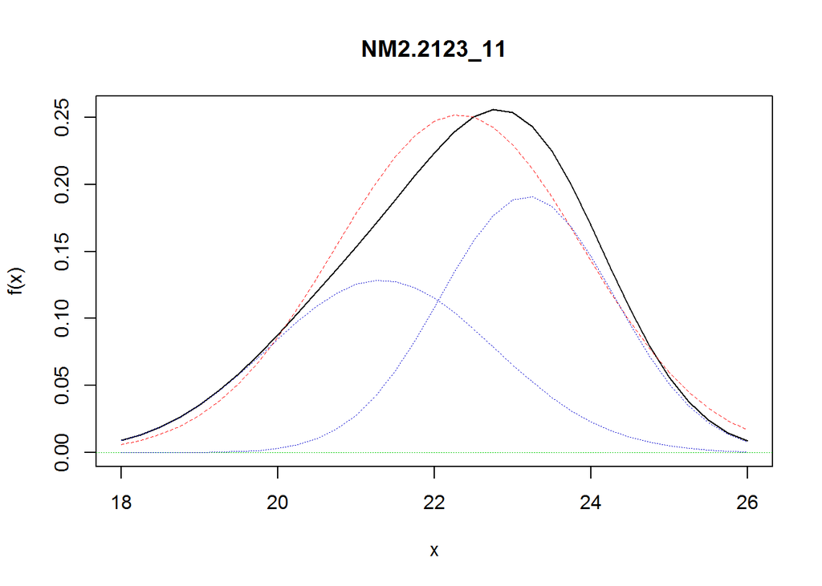

```r
plot(Classified.Mix.Model.Time,xout=seq(from=18,to=26,by=.25),p.norm=TRUE,p.comp=TRUE)
```

## 2.1 Separate the samples into clusters and explore their dependencies

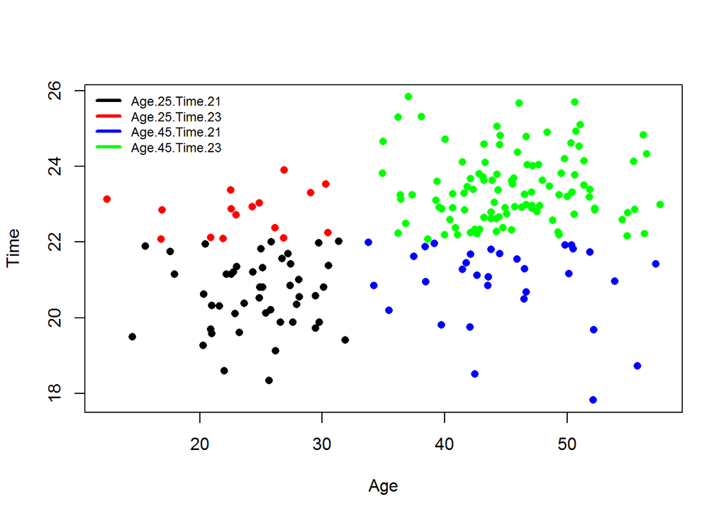

```r
#separate samples and explore dependencies
Age.Mixing.Sequence<-Age.Clusters$classification
Age.25.Time.21.Mixing.Sequence<-((Age.Clusters$classification==1)&(Time.Clusters$classification==1))
Age.25.Time.23.Mixing.Sequence<-((Age.Clusters$classification==1)&(Time.Clusters$classification==2))
Age.45.Time.21.Mixing.Sequence<-((Age.Clusters$classification==2)&(Time.Clusters$classification==1))
Age.45.Time.23.Mixing.Sequence<-((Age.Clusters$classification==2)&(Time.Clusters$classification==2))
Grouped.Data.Age.25.Time.21<-
  Grouped.Data.Age.25.Time.23<-
  Grouped.Data.Age.45.Time.21<-
  Grouped.Data.Age.45.Time.23<-
  cbind(Age=rep(NA,200),Time=rep(NA,200))
Grouped.Data.Age.25.Time.21[Age.25.Time.21.Mixing.Sequence,]<-
  Age.Time.Sample[Age.25.Time.21.Mixing.Sequence,]
Grouped.Data.Age.25.Time.23[Age.25.Time.23.Mixing.Sequence,]<-
  Age.Time.Sample[Age.25.Time.23.Mixing.Sequence,]
Grouped.Data.Age.45.Time.21[Age.45.Time.21.Mixing.Sequence,]<-
  Age.Time.Sample[Age.45.Time.21.Mixing.Sequence,]
Grouped.Data.Age.45.Time.23[Age.45.Time.23.Mixing.Sequence,]<-
  Age.Time.Sample[Age.45.Time.23.Mixing.Sequence,]
matplot(Age.Time.Sample[,1],cbind(Grouped.Data.Age.25.Time.21[,2],
                              Grouped.Data.Age.25.Time.23[,2],
                              Grouped.Data.Age.45.Time.21[,2],
                              Grouped.Data.Age.45.Time.23[,2]),
        pch=16,xlab="Age",ylab="Time",
        col=c('black','red', 'blue', 'green'))
legend('topleft', c("Age.25.Time.21","Age.25.Time.23","Age.45.Time.21","Age.45.Time.23") ,
   lty=1,lwd=3, col=c('black','red', 'blue', 'green'), bty='n', cex=.75)
```

Now we clearly see existence of clusters.

**Interpret the results: what dependencies do you see on the chart?**

Group the samples by age and by time and explore the dependencies within groups.

Group by age.

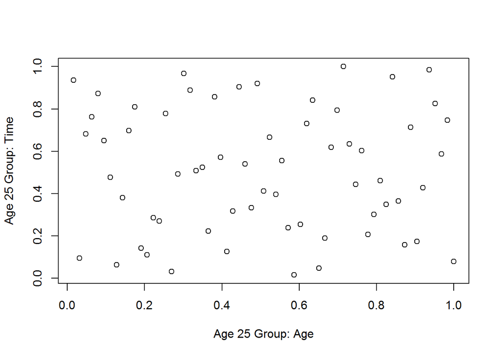

```r
#Group by age
Grouped.Data.Age.25<-cbind(Age=rep(NA,200),Time=rep(NA,200))
Grouped.Data.Age.25[Age.Clusters$classification==1,]<-Age.Time.Sample[Age.Clusters$classification==1,]
Grouped.Data.Age.45<-cbind(Age=rep(NA,200),Time=rep(NA,200))
Grouped.Data.Age.45[Age.Clusters$classification==2,]<-Age.Time.Sample[Age.Clusters$classification==2,]
plot(rank(na.omit(Grouped.Data.Age.25[,1]))/length(na.omit(Grouped.Data.Age.25[,1])),
     rank(na.omit(Grouped.Data.Age.25[,2]))/length(na.omit(Grouped.Data.Age.25[,2])),
     xlab="Age 25 Group: Age",ylab="Age 25 Group: Time")
```

```r
cor(na.omit(Grouped.Data.Age.25),method="spearman")[1,2]
```

```
## [1] -0.01128072
```

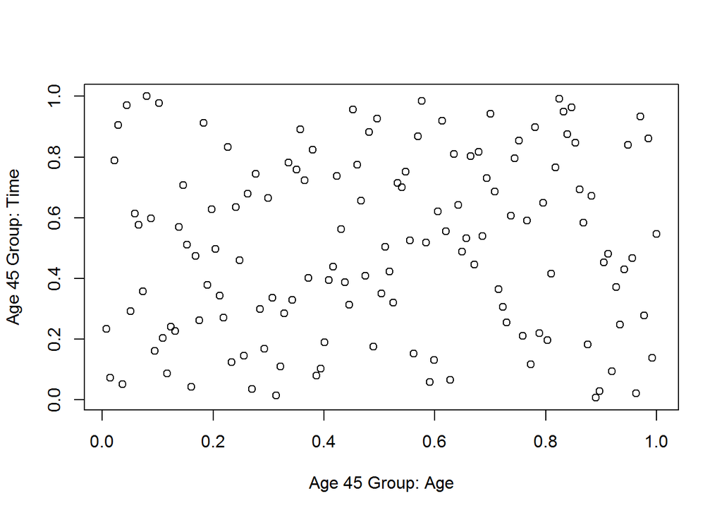

```r
plot(rank(na.omit(Grouped.Data.Age.45[,1]))/length(na.omit(Grouped.Data.Age.45[,1])),
     rank(na.omit(Grouped.Data.Age.45[,2]))/length(na.omit(Grouped.Data.Age.45[,2])),
     xlab="Age 45 Group: Age",ylab="Age 45 Group: Time")
```

```r
cor(na.omit(Grouped.Data.Age.45),method="spearman")[1,2]
```

```
## [1] 0.08611179
```

Group by time

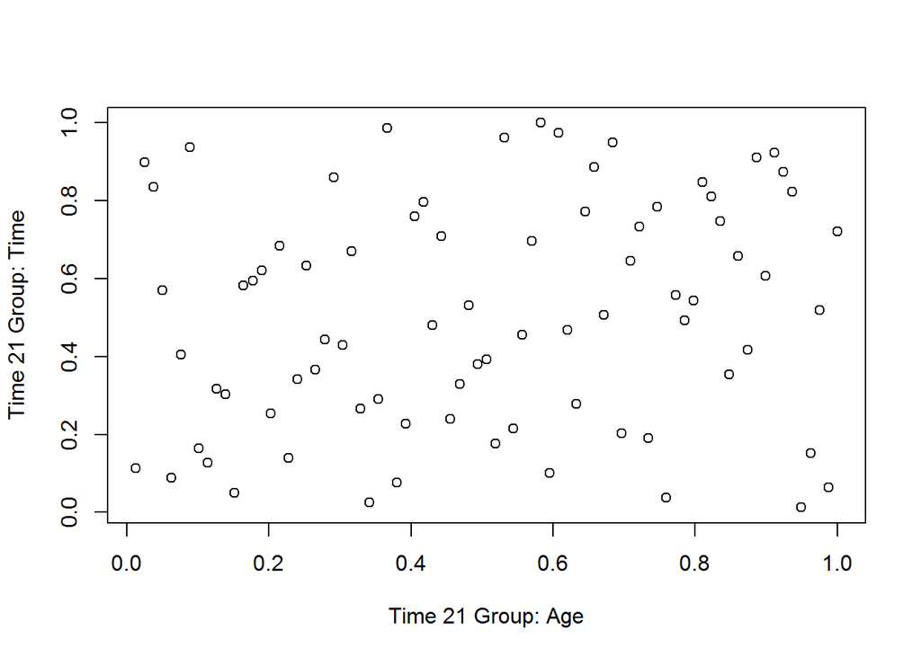

```r
#Group by Time
Grouped.Data.Time.21<-cbind(Age=rep(NA,200),Time=rep(NA,200))
Grouped.Data.Time.21[Time.Clusters$classification==1,]<-
  Age.Time.Sample[Time.Clusters$classification==1,]
Grouped.Data.Time.23<-cbind(Age=rep(NA,200),Time=rep(NA,200))
Grouped.Data.Time.23[Time.Clusters$classification==2,]<-
  Age.Time.Sample[Time.Clusters$classification==2,]
plot(rank(na.omit(Grouped.Data.Time.21[,1]))/length(na.omit(Grouped.Data.Time.21[,1])),
     rank(na.omit(Grouped.Data.Time.21[,2]))/length(na.omit(Grouped.Data.Time.21[,2])),
     xlab="Time 21 Group: Age",ylab="Time 21 Group: Time")
```

```r
cor(na.omit(Grouped.Data.Time.21),method="spearman")[1,2]
```

```
## [1] 0.1722736
```

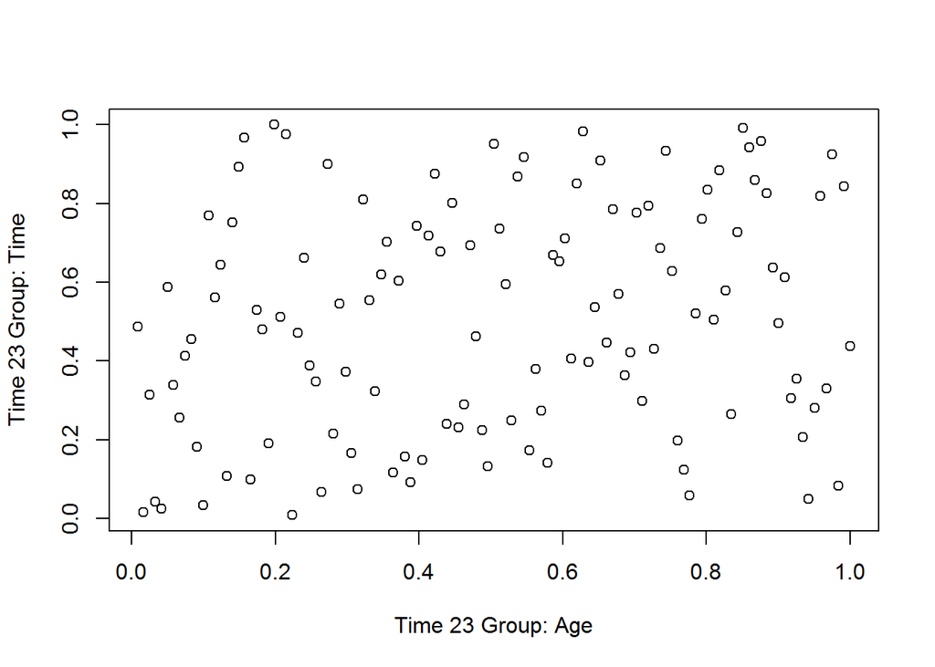

```r
plot(rank(na.omit(Grouped.Data.Time.23[,1]))/length(na.omit(Grouped.Data.Time.23[,1])),
     rank(na.omit(Grouped.Data.Time.23[,2]))/length(na.omit(Grouped.Data.Time.23[,2])),
     xlab="Time 23 Group: Age",ylab="Time 23 Group: Time")
```

```r
cor(na.omit(Grouped.Data.Time.23),method="spearman")[1,2]
```

```
## [1] 0.2115364
```

**What do you conclude from the results grouped by age and by time?**

Group by age and by time.

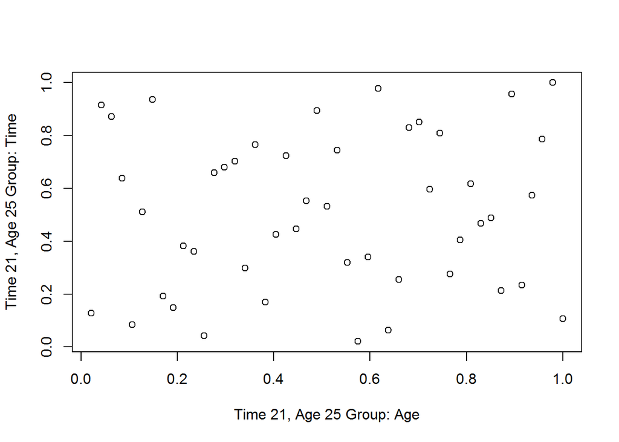

```r
#Group by Age and Time
#Grouped.Data.Age.25.Time.21
plot(rank(na.omit(Grouped.Data.Age.25.Time.21[,1]))/length(na.omit(Grouped.Data.Age.25.Time.21[,1])),
     rank(na.omit(Grouped.Data.Age.25.Time.21[,2]))/length(na.omit(Grouped.Data.Age.25.Time.21[,2])),
     xlab="Time 21, Age 25 Group: Age",ylab="Time 21, Age 25 Group: Time")
```

```r
cor(na.omit(Grouped.Data.Age.25.Time.21),method="spearman")[1,2]
```

```
## [1] 0.0793247
```

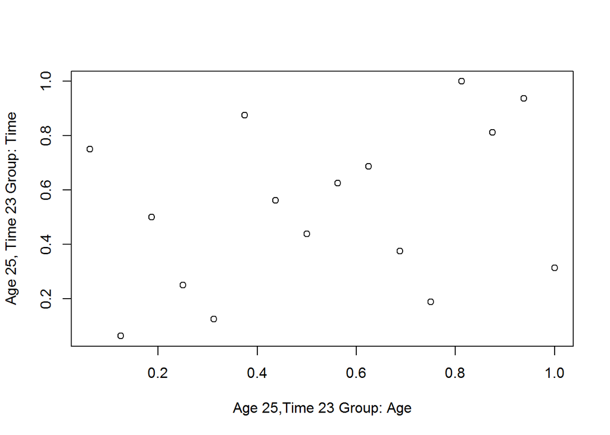

```r
#Grouped.Data.Age.25.Time.23
plot(rank(na.omit(Grouped.Data.Age.25.Time.23[,1]))/length(na.omit(Grouped.Data.Age.25.Time.23[,1])),
     rank(na.omit(Grouped.Data.Age.25.Time.23[,2]))/length(na.omit(Grouped.Data.Age.25.Time.23[,2])),
     xlab="Age 25,Time 23 Group: Age",ylab="Age 25, Time 23 Group: Time")
```

```r
cor(na.omit(Grouped.Data.Age.25.Time.23),method="spearman")[1,2]
```

```
## [1] 0.3176471
```

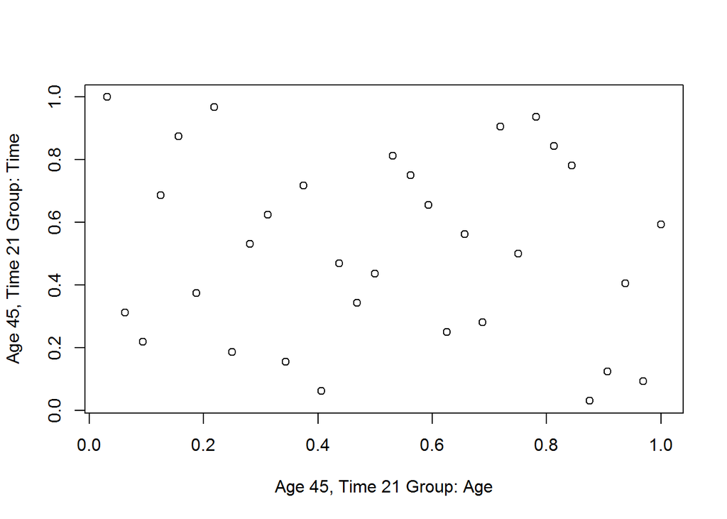

```r
#Grouped.Data.Age.45.Time.21
plot(rank(na.omit(Grouped.Data.Age.45.Time.21[,1]))/length(na.omit(Grouped.Data.Age.45.Time.21[,1])),
     rank(na.omit(Grouped.Data.Age.45.Time.21[,2]))/length(na.omit(Grouped.Data.Age.45.Time.21[,2])),
     xlab="Age 45, Time 21 Group: Age",ylab="Age 45, Time 21 Group: Time")
```

```r
cor(na.omit(Grouped.Data.Age.45.Time.21),method="spearman")[1,2]
```

```
## [1] -0.1257331
```

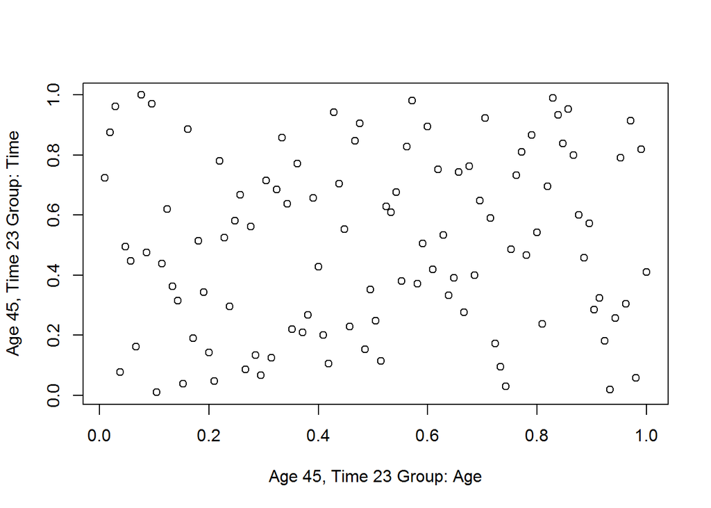

```r
#Grouped.Data.Age.45.Time.23
plot(rank(na.omit(Grouped.Data.Age.45.Time.23[,1]))/length(na.omit(Grouped.Data.Age.45.Time.23[,1])),
     rank(na.omit(Grouped.Data.Age.45.Time.23[,2]))/length(na.omit(Grouped.Data.Age.45.Time.23[,2])),
     xlab="Age 45, Time 23 Group: Age",ylab="Age 45, Time 23 Group: Time")
```

```r
cor(na.omit(Grouped.Data.Age.45.Time.23),method="spearman")[1,2]
```

```
## [1] 0.0871553
```

**Interpret the results of dependency analysis by age and time simultaneously**

Use `copula` to fit Gaussian copula to the groups `Age.25.Time.23` and `Age.45.Time.21`.  
Use `normalCopula()` to define the copula objects, then use `fitCopula()` to fit copulas. Use `pobs()` to create pseudo data that `fitCopula()` needs.  
Create the object `Gaussian.Copula.Age.25.Time.23.fit` of Gaussian copula fit to the group of age 25 and time 23 and explore it.

```r
library(copula)
```

(Skipped Code)

```r
Gaussian.Copula.Age.25.Time.23.fit
```

```
## Call: fitCopula(copula, data = data, method = "ml", optim.method = "BFGS",
##     optim.control = ..3)
## Fit based on "maximum likelihood" and 16 2-dimensional observations.
## Copula: normalCopula
##  rho.1
## 0.4412
## The maximized loglikelihood is 0.9922
## Optimization converged
```

```r
pobs(na.omit(Grouped.Data.Age.25.Time.23),ties.method = "average")
```

```
##              Age       Time
##  [1,] 0.35294118 0.82352941
##  [2,] 0.82352941 0.76470588
##  [3,] 0.11764706 0.05882353
##  [4,] 0.29411765 0.11764706
##  [5,] 0.70588235 0.17647059
##  [6,] 0.94117647 0.29411765
##  [7,] 0.52941176 0.58823529
##  [8,] 0.17647059 0.47058824
##  [9,] 0.47058824 0.41176471
## [10,] 0.58823529 0.64705882
## [11,] 0.64705882 0.35294118
## [12,] 0.23529412 0.23529412
## [13,] 0.05882353 0.70588235
## [14,] 0.41176471 0.52941176
## [15,] 0.76470588 0.94117647
## [16,] 0.88235294 0.88235294
```

Repeat the analysis for the group age 45 and time 21.

(Skipped Code)

```r
Gaussian.Copula.Age.45.Time.21.fit
```

```
## Call: fitCopula(copula, data = data, method = "ml", optim.method = "BFGS",
##     optim.control = ..3)
## Fit based on "maximum likelihood" and 32 2-dimensional observations.
## Copula: normalCopula
##   rho.1
## -0.2647
## The maximized loglikelihood is 0.7887
## Optimization converged
```

**Compare the correlations of the parametric models for both groups with Spearman correlations estimated earlier**

# 3 Test 3

[interactive chart not shown]